# OpenStreetMap Data Case Study

Map Area - *Orem, UT, United States* (data from OpenStreetMaps.org)

```
• https://www.openstreetmap.org/relation/198900#map=12/40.3130/-111.6300
• https://www.openstreetmap.org/export#map=12/40.3130/-111.6300
```

I have lived in Utah most of my life. Unfortunately, the places I have lived were too small to use for this case study. So I selected a larger town, Orem Utah.

## Auditing (checking for problems)

#### Audit #1 - State

The first item I decided to check was the state. I wanted to make sure the state was consistently entered as a 2 digit code, UT.  
*The state audit found these issues with the State...

*Counter ({"UT": 15519, "Utah": 2229, "Ut": 105, "ut": 6})*

It was discovered that the state code had indeed been entered in different ways. Around 87% of the time it was entered correctly as "UT". But the other 13% of the time, it was entered 3 different incorrect ways  
*("Utah", "Ut", and "ut")*.

#### Audit #2 - Street Name

The second item I decided to check was the street name. Consistency is the key! We want to keep things as consistent as possible. We will use the audit_street type function check for inconsistent data in the street name.  
*After running the audit2 function on element addr:street in our OSM file, I went through and identified the values that needed to be changed. List is below...

*Summary of the items that need to be changed (75 total items). Here is our discrepancy list and correct values to insert.*

16 Inconsistent items found: Ave, Dr, DrIve, E, Grove), lane, N, N., Pkwy, Rd, Rd., S, St, St., street, W

### Cleaning phase

Below are the functions we will use to clean the state field. We need to change the addr:state elements "Utah", "Ut", and "ut" to "UT".  
And the function used to clean the street field (addr:street). This will be used during the shaping of the data.  
*We include a list of expected values for both functions*  
*We include a mapping of the incorrect to correct values that we want to end up with.*

```python
#CLEANING STATES
state_re = re.compile(r'\b\S+\.?$', re.IGNORECASE)
expected_states = ["UT"]
mapping_states = { "Utah": "UT", "Ut": "UT", "ut": "UT"}

def update_state(name, mapping_states):
    m = state_re.search(name)
    if m.group() in mapping_states.keys():
        name = name[:len(name)-len(m.group())] + mapping_states[m.group()]
    return name
def update_state_name(state_name, mapping_states):
    m = state_re.search(state_name)
    if m:
        state = m.group()
        if state not in expected_states:
            print state
            state_name = update_name(state_name, mapping_states)
            print state_name
    return state_name

#CLEANING STREET_TYPES
expected = ["Street", "Avenue", "Boulevard", "Drive", "Court", "Place", "Square"] #NOT A COMPLETE LIST
mapping = { "St": "Street", "St.": "Street", "street": "Street", "Ave": "Avenue"} #NOT A COMPLETE LIST
def update_name(name, mapping):
    m = street_type_re.search(name)
    if m.group() in mapping.keys():
        name = name[:len(name)-len(m.group())] + mapping[m.group()]
    return name
def update_street_type(street_name, mapping):
    m = street_type_re.search(street_name)
    if m:
        street_type = m.group()
        if street_type not in expected:
            print street_type
            street_name = update_name(street_name, mapping)
            print street_name
    return street_name
```

### Preparing the data to be inserted into a SQL database.

*Shaping the Elements* After the auditing phase, the next step is preparing the data to be inserted into a SQL (Sqlite) database. We had to parse the elements in the OSM file, and transform them into tabular format (originally document format). The tabular format is necessary in order to write to .csv files.  
*All code for this part, except the shape_element function, was provided by the lesson.*

*shape_element function* The shape_function shapes and cleans the dataset.This element is quite long, please refer to the complete_shape_element.py for the full function. Below are a few highlights of the function  
1) The shape_element Cleans and shapes nodes or ways XML element to a Python Dict.  
2) First we went over the node field, loop node field header looking for key properties which will be placed in the node attribs dictionary.  
3) Looped through the child to tag the element values.  
4) Ran the cleaning function for state, and street type.  
5) Then repeated this process for the Ways.  
*Once this code was processed, the 5 .csv files were waiting in a folder, ready to be imported into a database.*

### Creating the Database

Once the dataset was thoroughly audited, cleaned, and converted from XML to CSV format. The cleaned .csv files were imported into a SQL database using this schema schema.sql in the folder.  
I was able to successfully create the database, and import the schema and tables through Python code. But, I was not able to import the .csv files through running code. I ran into problem after problem and eventually opted to just import the tables manually using the Sqlite Terminal.  
Then from the Sqlite Terminal, I imported the csv files into the newly created tables. Once all the csv files were loaded, I was ready to start exploring the dataset.

### Statistical Overview of the dataset (Exploring)

*FILE SIZES*  
80.74 MB example.osm  
80.74 MB OREM.osm  
42.78 MB OpenStreetMapSqlite.db  
30.07 MB nodes.csv  
0.95 MB nodes_tags.csv  
2.63 MB ways.csv  
5.54 MB ways_tags.csv  
10.26 MB ways_nodes.csv

#### Unique number of Users = 925

```python
SELECT COUNT(DISTINCT(combined.uid)) as "Unique User Count"
FROM (SELECT uid FROM nodes UNION ALL SELECT uid FROM ways) combined;
```

#### Number of Nodes = 367494

```python
SELECT COUNT(*) as "Total node count"
FROM nodes;
```

#### Number of Ways = 45162

```python
SELECT COUNT(*) as "Total way count"
FROM ways;
```

#### Top 10 Contributing Users (nodes + ways)

Top user was OremSteve with a total count of 81745  
The remaining 9 had counts ranging from 8970 to 25619.

```python
SELECT combined.user, count(*) as "Total Count"
FROM (SELECT user FROM nodes UNION ALL SELECT user FROM ways) combined
Group BY combined.user
ORDER BY "Total Count" DESC LIMIT 10;
```

#### Amenity Summary (for amenities with total count > 5)

Parking is by far the largest amenity in Orem, UT - with a grand total of 1043.  
Followed by Shelter 224, Churches 158, and Schools 101.

```python
SELECT key, value as Amenity, Count(*) AS "Total Count"
FROM Ways_tags
GROUP BY key, value
HAVING key='amenity' and "Total Count" > 5
ORDER BY "Total Count" DESC;
```

### Additional ideas for improvement - Auditing and Updating postal codes

Postal codes/zip codes are another area that could be audited for consistency. We will take a quick look to see what we find.

```python
def audit_postal_codes(osmfile):   ## Auditing postal codes function
    postcode_list =[]
    osm_file = open(osmfile, "r")
    for event,element in ET.iterparse(osmfile):
        for elem in element.iter("tag"):
            if elem.attrib['k'] == "addr:postcode":
                postcode_list.append(elem.attrib['v'])
    pprint.pprint(Counter(postcode_list))
    osm_file.close()
```

Now that we have a function to check, let's take a look.

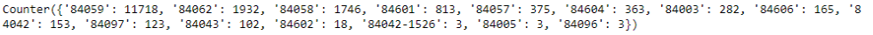

Here we can see there is an issue with some of the postal codes in the data set. We could have some incorrect zip codes entered (the ones were there are only a few of each zip). However, that would require further analysis to determine if that is true.  
Additionally, we want to keep the postal codes as 5 digits codes. We only have 3 that have been extended to include the extra 4 digits.

#### Cost/Benefits of Cleaning Postal code values

A potential downside to systematically cleaning is that you may inadvertently delete or eliminate pertinent data in the process. Postal codes in the United States contain 5 digits, but each postal code has an extra +4 digits on the end, making a full 9 digit postal code. These extra 4 digits refer to a geographical area, sometimes a village, a certain section of a large city, a sector/segment, or one side of a street. It divides the zip code into smaller areas. So removing the extra 4 digits could reduce the accuracy of the postal code field. Reference: https://faq.usps.com/s/article/ZIP-Code-The-Basics

A potential benefit to standardizing the postal code data is it would allow us better analysis on the area in full. Running our ameninty report for example, if we wanted to break it down further by adding on location (postal code). We would get more accurate insights from the data if grouped by the 5 digit postal code, vs grouping by a 9 digit postal code.

### Conclusion

This was a really challenging project for me. There were lots of steps and hopefully nothing was missed. In a case study like this, you want to make sure to fully audit and clean the data before making decisions on it.

In my review of the Orem, UT OSM dataset, I found that most of the data is pretty consistent throughout. Minor problems here and there, nothing major. One area, in particular, that could be improved on is cardinal directions. In Utah, we have many addresses that have two directions in them (ie 500 S 100 W). A naming convention with validation could be implemented to stop the cardinal directions from being entered in different ways. The other changes we made to the street names and the state, were only made in this case study. No changes were submitted to Openstreetmap.org.

This is a big dataset, there are many more areas that could be explored.